# Artificial Intelligence 🪐

# CA 4 - Regression, Classification, Ensemble, SVM

# Amirali Shahriary (810100173)

## Introduction:

### Necessarly libraries :

```python
import pandas as pd
import numpy as np
import math
import matplotlib.pyplot as plt
import seaborn as sns
import missingno as msno
from sklearn.impute import KNNImputer
from sklearn.model_selection import train_test_split, GridSearchCV
from scipy import stats
from sklearn import preprocessing
from sklearn.tree import DecisionTreeClassifier, plot_tree
from sklearn.neighbors import KNeighborsClassifier
from sklearn.metrics import accuracy_score, classification_report,confusion_matrix,f1_score
from sklearn.ensemble import RandomForestClassifier
from sklearn.model_selection import GridSearchCV, RandomizedSearchCV
from sklearn.preprocessing import LabelEncoder
from xgboost import XGBClassifier
from sklearn.svm import SVC
from scipy.stats import uniform, reciprocal
```

# section1 - EDA :

### 1.Obtain the general structure of the data:

```python
data = pd.read_excel("/home/amirali/Desktop/AI/CA4/DataSet.xlsx")

print (" Data Info :")
print(data.info())
print (" Data Describe :")
print(data.describe())
```

```
 Data Info :
<class 'pandas.core.frame.DataFrame'>
RangeIndex: 506 entries, 0 to 505
Data columns (total 14 columns):
 #   Column   Non-Null Count  Dtype
---  ------   --------------  -----
 0   CRIM     506 non-null    float64
 1   ZN       506 non-null    float64
 2   INDUS    506 non-null    float64
 3   CHAS     480 non-null    float64
 4   NOX      506 non-null    float64
 5   RM       506 non-null    float64
 6   AGE      506 non-null    float64
 7   DIS      479 non-null    float64
 8   RAD      506 non-null    int64
 9   TAX      506 non-null    float64
 10  PTRATIO  506 non-null    float64
 11  B        486 non-null    float64
 12  LSTAT    506 non-null    float64
 13  MEDV     452 non-null    float64
dtypes: float64(13), int64(1)
memory usage: 55.5 KB
None
 Data Describe :
             CRIM          ZN       INDUS        CHAS         NOX          RM  \
count  506.000000  506.000000  506.000000  480.000000  506.000000  506.000000
mean     1.269195   13.295257    9.205158    0.175000    1.101175   15.679800
std      2.399207   23.048697    7.169630    0.380364    1.646991   27.220206
min      0.000000    0.000000    0.000000    0.000000    0.385000    3.561000
25%      0.049443    0.000000    3.440000    0.000000    0.449000    5.961500
50%      0.144655    0.000000    6.960000    0.000000    0.538000    6.322500
75%      0.819623   18.100000   18.100000    0.000000    0.647000    6.949000
max      9.966540  100.000000   27.740000    1.000000    7.313000  100.000000

              AGE         DIS         RAD         TAX     PTRATIO           B  \
count  506.000000  479.000000  506.000000  506.000000  506.000000  486.000000
mean    58.744660    6.211663   78.063241  339.317787   42.614980  336.820947
std     33.104049    6.527286  203.542157  180.670077   87.585243  121.174519
min      1.137000    1.129600    1.000000   20.200000    2.600000    0.320000
25%     32.000000    2.425900    4.000000  254.000000   17.000000  370.415000
50%     65.250000    3.917500    5.000000  307.000000   18.900000  390.885000
75%     89.975000    6.341400   24.000000  403.000000   20.200000  395.630000
max    100.000000   24.000000  666.000000  711.000000  396.900000  396.900000

            LSTAT        MEDV
count  506.000000  452.000000
mean    11.537806   23.750442
std      6.064932    8.808602
min      1.730000    6.300000
25%      6.877500   18.500000
50%     10.380000   21.950000
75%     15.015000   26.600000
max     34.410000   50.000000
```

### 2.Identify missing data:

```python
missing_values = data.isnull().sum()
print("Number of missing values:")
print(missing_values)
print("\nRatio of missing values:")
print(missing_values / len(data))
```

```
Number of missing values:
CRIM        0
ZN          0
INDUS       0
CHAS       26
NOX         0
RM          0
AGE         0
DIS        27
RAD         0
TAX         0
PTRATIO     0
B          20
LSTAT       0
MEDV       54
dtype: int64

Ratio of missing values:
CRIM       0.000000
ZN         0.000000
INDUS      0.000000
CHAS       0.051383
NOX        0.000000
RM         0.000000
AGE        0.000000
DIS        0.053360
RAD        0.000000
TAX        0.000000
PTRATIO    0.000000
B          0.039526
LSTAT      0.000000
MEDV       0.106719
dtype: float64
```

### 3.Graph the number of unique values for each feature:

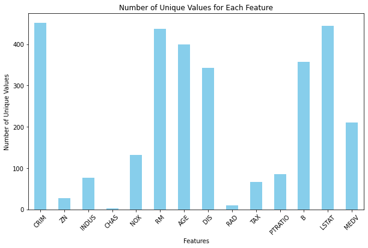

```python
unique_counts = data.nunique()

plt.figure(figsize=(10, 6))
unique_counts.plot(kind='bar', color='skyblue')
plt.title('Number of Unique Values for Each Feature')
plt.xlabel('Features')
plt.ylabel('Number of Unique Values')
plt.xticks(rotation=45)
plt.show()
```

### 4.Draw a diagram of the dependence of the features on each other:

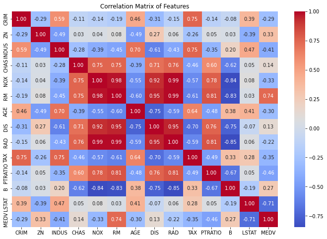

```python
corr_matrix = data.corr()

plt.figure(figsize=(12, 8))
sns.heatmap(corr_matrix, annot=True, cmap='coolwarm', fmt=".2f")
plt.title('Correlation Matrix of Features')
plt.show()
```

### 5.Scatter and hexbin charts for checking relationships with the target column:

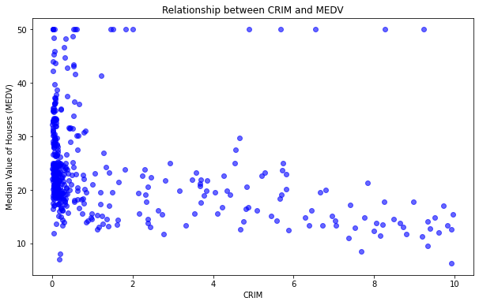

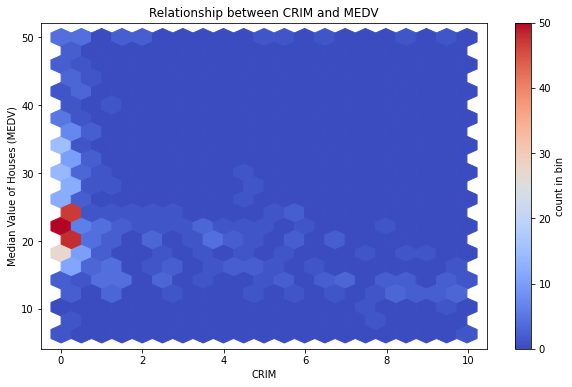

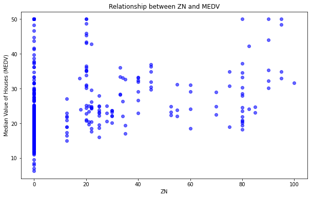

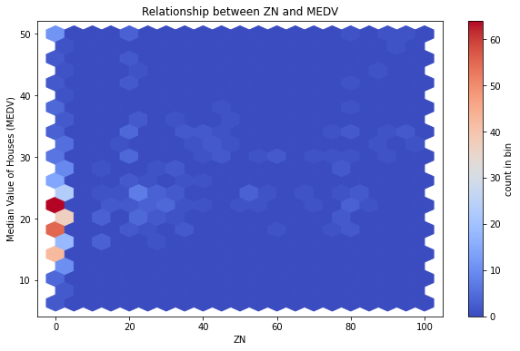

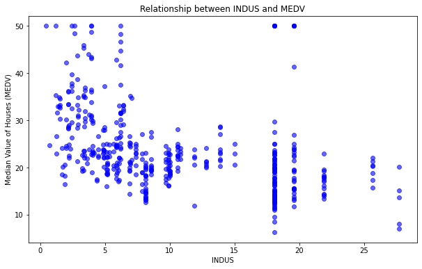

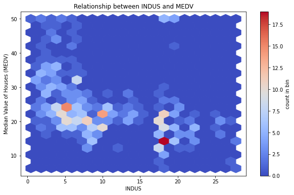

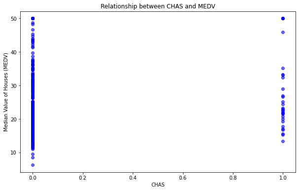

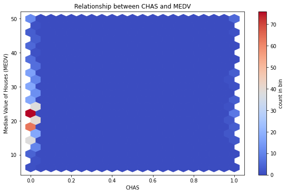

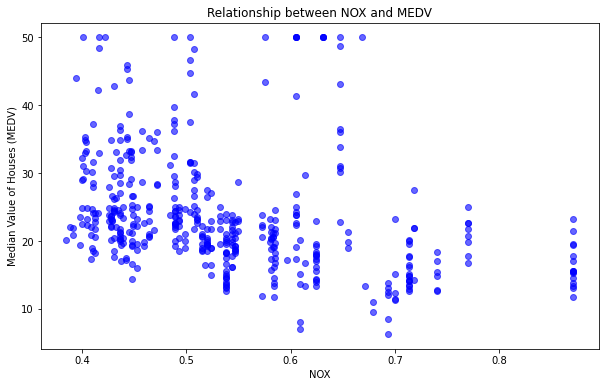

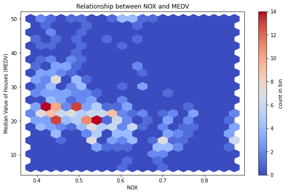

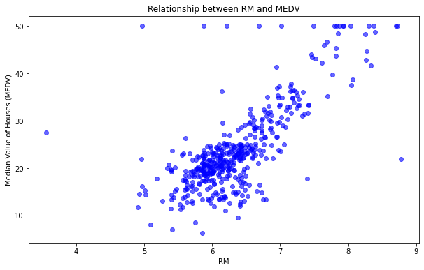

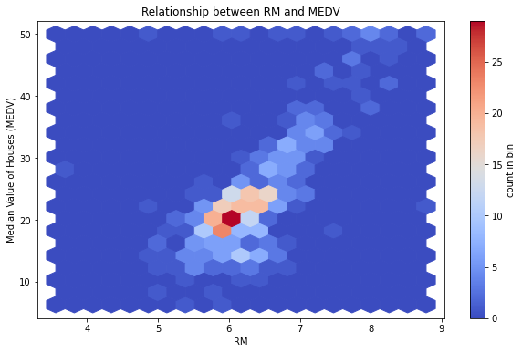

[14 more figures not shown]

```python
designated_feature_list = ['CRIM', 'ZN', 'INDUS', 'CHAS', 'NOX', 'RM', 'AGE', 'DIS', 'RAD', 'TAX', 'PTRATIO', 'B', 'LSTAT']

for feature in designated_feature_list:

    # Scatter
    plt.figure(figsize=(10, 6))
    plt.scatter(data[feature], data['MEDV'], alpha=0.6, color='blue')
    plt.title(f'Relationship between {feature} and MEDV')
    plt.xlabel(f'{feature}')
    plt.ylabel('Median Value of Houses (MEDV)')
    plt.show()

    # Hexbin
    plt.figure(figsize=(10, 6))
    plt.hexbin(data[feature], data['MEDV'], gridsize=20, cmap='coolwarm')
    plt.colorbar(label='count in bin')
    plt.title(f'Relationship between {feature} and MEDV')
    plt.xlabel(f'{feature}')
    plt.ylabel('Median Value of Houses (MEDV)')
    plt.show()
```

- Scatter plots are useful for visualizing the relationship between two continuous variables. In this case, we're exploring the relationship between each factors of the dataset and the median value of homes (MEDV), where each point represents a data point.
- Hexbin plots are similar to scatter plots but are more suitable for visualizing large datasets. They aggregate points into hexagonal bins, and the color intensity represents the number of points in each bin.

### 6.Additional survey implementation:

We can check the distribution of every data , also we can use the below implementation for missing value matrix like below using msno.

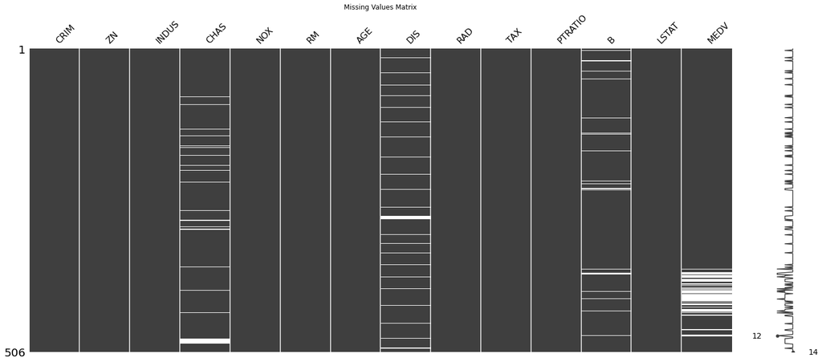

```python
msno.matrix(data)
plt.title('Missing Values Matrix')
plt.show()
```

✨✨✨✨✨✨✨✨✨✨✨✨✨✨✨✨✨✨✨✨✨✨✨✨✨✨✨✨✨✨✨✨✨✨✨✨✨✨✨✨✨✨

# Section 2 - Preprocess

### 7.Methods of Filling Missing Values:

They are several ways like removing the entire column and fill the empty values with statistics (for example, mode). If we have categorical data we can replace values with the category that has the most frequency. It is easy to implement but suffers from low perforamance if we have same amount of data in each category. We can use correlation and predict missing value using regression or classification. This method is more accurate but harder to implement.

```python
# Method 1: Mean/Median/Mode Imputation

# numerical
data_filled_mean = data.fillna(data.mean())
# categorical
data_filled_mode = data.fillna(data.mode().iloc[0])

# Method 2: Forward Fill/Backward Fill
data_filled_ffill = data.ffill()
data_filled_bfill = data.bfill()

# Method 3: K-Nearest Neighbors (KNN) Imputation
imputer = KNNImputer(n_neighbors=5)
data_filled_knn = pd.DataFrame(imputer.fit_transform(data), columns=data.columns)

print("Mean/Median Imputation:")
print(data_filled_mean.head())
print("\nForward Fill Imputation:")
print(data_filled_ffill.head())
print("\nKNN Imputation:")
print(data_filled_knn.head())
```

```
Mean/Median Imputation:
      CRIM    ZN  INDUS  CHAS    NOX     RM   AGE     DIS  RAD    TAX  \
0  0.00632  18.0   2.31   0.0  0.538  6.575  65.2  4.0900    1  296.0
1  0.02731   0.0   7.07   0.0  0.469  6.421  78.9  4.9671    2  242.0
2  0.02729   0.0   7.07   0.0  0.469  7.185  61.1  4.9671    2  242.0
3  0.03237   0.0   2.18   0.0  0.458  6.998  45.8  6.0622    3  222.0
4  0.06905   0.0   2.18   0.0  0.458  7.147  54.2  6.0622    3  222.0

   PTRATIO           B  LSTAT  MEDV
0     15.3  396.900000   4.98  24.0
1     17.8  396.900000   9.14  21.6
2     17.8  392.830000   4.03  34.7
3     18.7  336.820947   2.94  33.4
4     18.7  396.900000   5.33  36.2

Forward Fill Imputation:
      CRIM    ZN  INDUS  CHAS    NOX     RM   AGE     DIS  RAD    TAX  \
0  0.00632  18.0   2.31   0.0  0.538  6.575  65.2  4.0900    1  296.0
1  0.02731   0.0   7.07   0.0  0.469  6.421  78.9  4.9671    2  242.0
2  0.02729   0.0   7.07   0.0  0.469  7.185  61.1  4.9671    2  242.0
3  0.03237   0.0   2.18   0.0  0.458  6.998  45.8  6.0622    3  222.0
4  0.06905   0.0   2.18   0.0  0.458  7.147  54.2  6.0622    3  222.0

   PTRATIO       B  LSTAT  MEDV
0     15.3  396.90   4.98  24.0
1     17.8  396.90   9.14  21.6
2     17.8  392.83   4.03  34.7
3     18.7  392.83   2.94  33.4
4     18.7  396.90   5.33  36.2

KNN Imputation:
      CRIM    ZN  INDUS  CHAS    NOX     RM   AGE     DIS  RAD    TAX  \
0  0.00632  18.0   2.31   0.0  0.538  6.575  65.2  4.0900  1.0  296.0
1  0.02731   0.0   7.07   0.0  0.469  6.421  78.9  4.9671  2.0  242.0
2  0.02729   0.0   7.07   0.0  0.469  7.185  61.1  4.9671  2.0  242.0
3  0.03237   0.0   2.18   0.0  0.458  6.998  45.8  6.0622  3.0  222.0
4  0.06905   0.0   2.18   0.0  0.458  7.147  54.2  6.0622  3.0  222.0

   PTRATIO        B  LSTAT  MEDV
0     15.3  396.900   4.98  24.0
1     17.8  396.900   9.14  21.6
2     17.8  392.830   4.03  34.7
3     18.7  393.406   2.94  33.4
4     18.7  396.900   5.33  36.2
```

### 8.Deleting Columns:

It's possible to delete columns if they are irrelevant, redundant,or all values are the same, or contain too many missing values.

### 9.Numerical vs. Categorical Features:

Numerical features are continuous and represent quantities or measurements (e.g., age, price). Categorical features are discrete and represent categories or labels (e.g., color, city).

In this dataset, numerical features include CRIM, ZN, INDUS, NOX, RM, AGE, DIS, RAD, TAX, PTRATIO, B, LSTAT, and MEDV. Categorical features are CHAS (Charles River dummy variable).

### 10. Normalizing or Standardizing Numerical Features:

Normalization change scale of data between 0 and 1. It gives all features same importance and decreases the affect of outliers. It is mostly useful when we have features with different scales. It also helps convergence of ML algorithm. Standardization transforms data to have 0 mean and 1 standard derivation. This type of preprocessing is useful for statistical properties. It is commenly used in regression and neural networks. In this project we need to normalize or standardize the data because our features have different scales. In this project, it may be beneficial to normalize or standardize numerical features before training the model to ensure optimal performance, especially for algorithms sensitive to feature scaling like gradient descent-based methods.

### 11.Preprocessing Categorical Features:

Convert categorical features into numerical representations using techniques such as one-hot encoding or label encoding:

- One-hot encoding: Creates binary columns for each category, while label encoding assigns a unique integer to each category.
- Label Encoding: Assigns a unique integer to each category.Ideal for ordinal variables where the order matters but can introduce a notion of order for nominal variables that don't have any order which might not be suitable for some algorithms.

### 12.Data Segmentation:

Data is typically divided into three sets: training, validation, and test sets. The training set is used to train the model, the validation set is used to tune hyperparameters and evaluate model performance during training, and the test set is used to evaluate the final model performance.

```python
# train, validation, and test sets
X_train_val, X_test, y_train_val, y_test = train_test_split(X, y, test_size=0.2, random_state=42)
X_train, X_val, y_train, y_val = train_test_split(X_train_val, y_train_val, test_size=0.25, random_state=42) # 0.25 x 0.8 = 0.2
```

### 13.Other Preprocessing Methods:

- Feature scaling: Scaling numerical features to a similar range.
- Feature engineering: Creating new features from existing ones to improve model performance.
- Handling outliers: Removing or transforming outliers to prevent them from affecting the model disproportionately.
- Dimensionality reduction: Techniques like Principal Component Analysis (PCA) to reduce the number of features while preserving important information.

### Preprocess for this Dataset based on the previous part:

```python
columns_to_scale = ['CRIM', 'ZN', 'INDUS', 'NOX', 'RM', 'AGE', 'DIS', 'RAD', 'TAX', 'PTRATIO', 'B', 'LSTAT']

# Fill missing values for specific columns based on part 2:
data['CHAS'].fillna(0, inplace=True)
data['DIS'].fillna(5, inplace=True)
data['B'].fillna(data['B'].mean(), inplace=True)

data.dropna(subset=['MEDV'], inplace=True)

# winsorization to 'MEDV' column
temp = data['MEDV']
temp = np.array(temp)
data['MEDV'] = stats.mstats.winsorize(temp, limits=[0.1, 0.1])


for column in columns_to_scale:
    data[column] = preprocessing.scale(data[column])

# One-hot encode 'CHAS' column (get dummies)
data = pd.get_dummies(data, columns=['CHAS'])


print("Number of missing values after preprocessing:")
print(data.isnull().sum())


print("Preprocessed data:")
print(data.head())
```

```
Number of missing values after preprocessing:
CRIM        0
ZN          0
INDUS       0
NOX         0
RM          0
AGE         0
DIS         0
RAD         0
TAX         0
PTRATIO     0
B           0
LSTAT       0
MEDV        0
CHAS_0.0    0
CHAS_1.0    0
dtype: int64
Preprocessed data:
       CRIM        ZN     INDUS       NOX        RM       AGE       DIS  \
0 -0.567361  0.217241 -1.177523 -0.024767  0.347505 -0.012741 -0.003970
1 -0.558942 -0.523527 -0.476449 -0.631681  0.116298  0.474875  0.420596
2 -0.558950 -0.523527 -0.476449 -0.631681  1.263325 -0.158670  0.420596
3 -0.556912 -0.523527 -1.196670 -0.728436  0.982574 -0.703233  0.950687
4 -0.542200 -0.523527 -1.196670 -0.728436  1.206274 -0.404257  0.950687

        RAD       TAX   PTRATIO         B     LSTAT  MEDV  CHAS_0.0  CHAS_1.0
0 -0.905491 -0.538783 -1.341047  0.410452 -1.050777  24.0      True     False
1 -0.772780 -0.896020 -0.203457  0.410452 -0.374312  21.6      True     False
2 -0.772780 -0.896020 -0.203457  0.351046 -1.205258  34.7      True     False
3 -0.640068 -1.028330  0.206075 -0.466463 -1.382504  33.4      True     False
4 -0.640068 -1.028330  0.206075  0.410452 -0.993863  35.4      True     False
```

✨✨✨✨✨✨✨✨✨✨✨✨✨✨✨✨✨✨✨✨✨✨✨✨✨✨✨✨✨✨✨✨✨✨✨✨✨✨✨✨✨✨

# Section 3 - Training, evaluation and regulation

## Phase 1 - Linear Regression:

### 14. Supervised, Unsupervised, Semi-Supervised & Reinforcement Learning:

- Supervised Learning:

In supervised learning, the algorithm learns from labeled data.The goal is to learn a mapping from inputs to outputs.

Example: Classification(Email has or spam detection) and Regression(House price prediction).

- Unsupervised Learning:

Unsupervised learning deals with unlabeled data, where the algorithm tries to find patterns or structures in the data without explicit supervision.

Example: Clustering(cluster customer data) and Dimensionality Reduction(PCA).

- Semi-Supervised Learning:

Semi-supervised learning is a mixture of supervised and unsupervised learning. It uses a small amount of labeled data along with a large amount of unlabeled data.

Example: Context of image classification, you might have a small set of images labeled with categories (supervised data), but a large set of unlabeled images. The model can leverage the small labeled set along with the large unlabeled set to improve its performance.

- Reinforcement Learning:

Reinforcement learning involves an agent learning to make decisions by interacting with an environment. The agent learns from trial and error, receiving feedback in the form of rewards or penalties. Example: Game Playing(Play chess) and Robotics(Maze navigation).

### 15. Difference between Regression and Classification:

- Regression:

Regression is used when the target variable is continuous, meaning it can take any real value within a specific range.

In regression, the output variable is numeric, and the model tries to learn the relationship between the input features and the continuous target variable.

- Classification:

Classification is used when the target variable is categorical, meaning it falls into one of a finite number of classes or categories. The goal of classification is to assign input data points to one of several predefined classes or categories. In classification, the output variable is categorical, and the model learns to classify input data into different classes based on the features.

- Differences:

Nature of Output:

Regression predicts continuous values, while classification predicts categorical values .

Evaluation Metrics:

In regression, evaluation metrics often include mean squared error (MSE), root mean squared error (RMSE), mean absolute error (MAE); which measure the difference between predicted and actual continuous values. In classification, evaluation metrics include accuracy, precision, recall, F1-score, ROC AUC, etc., which assess the correctness of class assignments.

Algorithms:

### 16-17. Linear Regression relations:

Main form of simple linear regression function: $$f(x) = \alpha x + \beta$$

- step 1: Compute RSS of the training data

$$ RSS = \Sigma (y_i - (\hat{\beta} + \hat{\alpha} * x_i) )^2 $$

- step 2: Compute the derivatives of the RSS function in terms of $\alpha$ and $\beta$, and set them equal to 0 to find the desired parameters

$$ \frac{\partial RSS}{\partial \beta} = \Sigma (-f(x_i) + \hat{\beta} + \hat{\alpha} * x_i) = 0$$$$ \to \beta = \hat{y} - \hat{\alpha} \hat{x} \to (1)$$$$ \frac{\partial RSS}{\partial \alpha} = \Sigma (-2 x_i y_i + 2 \hat{\beta} x_i + 2\hat{\alpha} x_i ^ 2) = 0 \to (2)$$$$ (1) , (2) \to \hat{\alpha} = \frac{\Sigma{(x_i - \hat{x})(y_i - \hat{y})}}{\Sigma{(x_i - \hat{x})^2}} $$$$ \hat{\beta} = y - \hat{a} x$$

Based on the above formula, implement the function below to compute the parameters of a simple linear regression

```python
def linear_regression(given_input, output):
    alpha = np.dot(given_input - np.mean(given_input), output - np.mean(output)) / np.sum(np.power(given_input - np.mean(given_input), 2))
    beta = np.mean(output) - (alpha * np.mean(given_input))
    return alpha, beta
```

Now complete this `get_regression_predictions(...)` function to predict the value of given data based on the calculated intercept and slope

```python
def get_regression_predictions(given_input, intercept, slope):
    return (given_input * slope) + intercept
```

Now that we have a model and can make predictions, let's evaluate our model using Root Mean Square Error (RMSE). RMSE is the square root of the mean of the squared differences between the residuals, and the residuals is just a fancy word for the difference between the predicted output and the true output.

Complete the following function to compute the RSME of a simple linear regression model given the input_feature, output, intercept and slope:

```python
def get_root_mean_square_error(predicted_values, actual_values):
    return math.sqrt(np.sum(np.power(actual_values - predicted_values, 2)) / len(actual_values))
```

The RMSE has no bound, thus it becomes challenging to determine whether a particular RMSE value is considered good or bad without any reference point. Instead, we use R2 score. The R2 score is calculated by comparing the sum of the squared differences between the actual and predicted values of the dependent variable to the total sum of squared differences between the actual and mean values of the dependent variable. The R2 score is formulated as below:

$$R^2 = 1 - \frac{SSres}{SStot} = 1 - \frac{\sum_{i=1}^{n} (y_{i,true} - y_{i,pred})^2}{\sum_{i=1}^{n} (y_{i,true} - \bar{y}_{true})^2} $$

Complete the following function to calculate the R2 score of a given input_feature, output, bias, and slope:

```python
def get_r2_score(predicted_values, actual_values):
    r2_score = 1 - (np.sum(np.power(actual_values - predicted_values, 2)) / np.sum(np.power(actual_values - np.mean(predicted_values), 2)))
    return r2_score
```

Now calculate the fitness of the model.

### 18. Evaluation Methods:

- Root Mean Square Error (RMSE):

RMSE is a metric used to measure the average magnitude of the errors between predicted and actual values in regression analysis. It is calculated by taking the square root of the average of the squared differences between predicted and actual values. RMSE provides a measure of how spread out the residuals (the differences between predicted and actual values) are. Lower RMSE values indicate better model performance, as they imply that the model's predictions are closer to the actual values.

Formula: $[ RMSE = \sqrt{MSE} = \sqrt{\frac{1}{n} \Sigma_{i=1}^{n} (y_i - \hat{y_i})^2} ]$

- Mean Squared Error (MSE):

MSE is another metric used to measure the average squared differences between predicted and actual values in regression analysis. It is calculated by taking the average of the squared differences between predicted and actual values. MSE is directly related to RMSE, as RMSE is the square root of MSE. Like RMSE, lower MSE values indicate better model performance.

formula: $[ MSE = \frac{1}{n} \Sigma_{i=1}^{n} (y_i - \hat{y_i})^2 ]$

- Residual Sum of Squares (RSS):

RSS is a measure used in regression analysis to quantify the amount of variance in the data that is not explained by the regression model. It is calculated by summing the squared differences between predicted and actual values for each data point. RSS is used to assess how well the regression model fits the data: a lower RSS indicates a better fit. RSS is closely related to MSE, as MSE can be considered as RSS divided by the number of observations.

Formula: $[ RSS = \Sigma_{i=1}^{n} (y_i - \hat{y_i})^2 ]$

- R-squared (R2) Score:

R2 score is a statistical measure that represents the proportion of the variance in the dependent variable (target) that is explained by the independent variables (features) in a regression model. It ranges from 0 to 1, where 0 indicates that the model does not explain any of the variability of the response data around its mean, and 1 indicates that the model explains all the variability of the response data. R2 score of 1 indicates a perfect fit, where the model explains all the variance in the target variable. A score of 0 indicates that the model does not explain any variance beyond the mean of the target variable.

Formula: $4[ R^2 = 1 - \frac{RSS}{TSS} = 1 - \frac{\Sigma (y_i - \hat{y_i})^2}{\Sigma (y_i - \bar{y})^2} ]$

### 18.RMSE & R2 score evaluation:

```
Attribute: CRIM
RMSE ERROR: 6.069729054568452
R2 SCORE: 0.09103704324189843
```

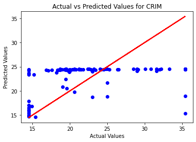

```
Attribute: ZN
RMSE ERROR: 5.343525842563418
R2 SCORE: 0.315413820916708
```

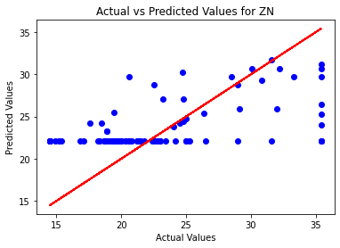

```
Attribute: INDUS
RMSE ERROR: 5.459275051327345
R2 SCORE: 0.26798796902741917
```

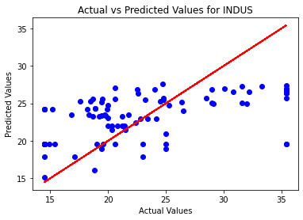

```
Attribute: NOX
RMSE ERROR: 5.631818522163907
R2 SCORE: 0.24043457963785153
```

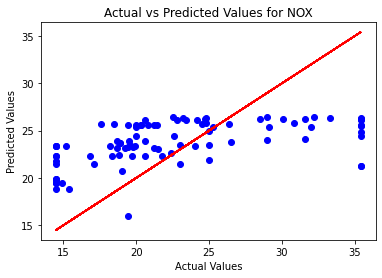

```
Attribute: RM
RMSE ERROR: 4.355875612348023
R2 SCORE: 0.5312632618297768
```

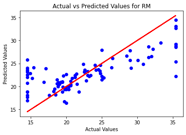

```
Attribute: AGE
RMSE ERROR: 5.579142959449403
R2 SCORE: 0.2453030322645977
```

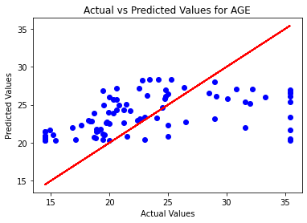

```
Attribute: DIS
RMSE ERROR: 6.093132730373496
R2 SCORE: 0.09551084856746739
```

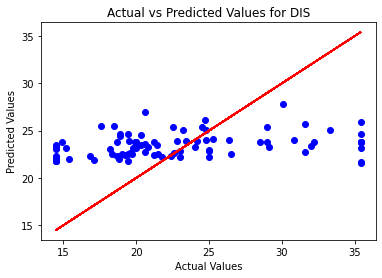

```
Attribute: RAD
RMSE ERROR: 6.149524965928705
R2 SCORE: 0.06898423467103465
```

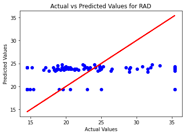

```
Attribute: TAX
RMSE ERROR: 5.811399303273103
R2 SCORE: 0.16791766658532337
```

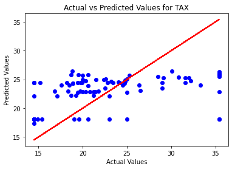

```
Attribute: PTRATIO
RMSE ERROR: 5.516216122966598
R2 SCORE: 0.2470007664627265
```

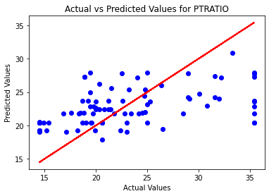

```
Attribute: B
RMSE ERROR: 6.185090179483867
R2 SCORE: 0.06141732226512697
```

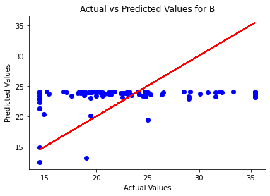

```
Attribute: LSTAT
RMSE ERROR: 3.955647376240919
R2 SCORE: 0.617899427260086
```

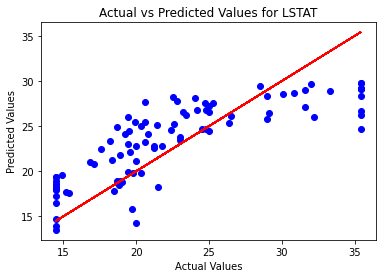

```
Attribute: CHAS_0.0
RMSE ERROR: 6.331451851098744
R2 SCORE: 0.01358613862355329
```

[2 more figures not shown]

```python
attributes = data.columns.drop('MEDV')

for attribute in attributes:
    x = data[attribute].to_numpy()
    y = data['MEDV'].to_numpy()

    # Split data into training and testing sets (we also did it previously)
    x_train, x_test, y_train, y_test = train_test_split(x, y, test_size=0.2, random_state=42)

    alpha, beta = linear_regression(x_train, y_train)

    y_pred = get_regression_predictions(x_test, beta, alpha)

    # evaluation with RMSE and R2 score
    rmse = get_root_mean_square_error(y_pred, y_test)
    r2_score = get_r2_score(y_pred, y_test)

    print(f"Attribute: {attribute}")
    print(f"RMSE ERROR: {rmse}")
    print(f"R2 SCORE: {r2_score}")

    plt.scatter(y_test, y_pred, color='blue')
    plt.plot(y_test, y_test, color='red')  # y = x line
    plt.xlabel('Actual Values')
    plt.ylabel('Predicted Values')
    plt.title(f'Actual vs Predicted Values for {attribute}')
    plt.show()
```

evaluation:

RMSE Error:

RMSE measures the average deviation of predicted values from actual values. Lower RMSE values indicate better model performance. The RMSE error values range from approximately 3.96 to 6.33.

R2 Score:

R2 score measures the proportion of the variance in the dependent variable (target) that is explained by the independent variables (features) in the model. A higher R2 score indicates better fit. The R2 scores range from approximately 0.013 to 0.618.

Based on these evaluations:

Features such as "RM" and "LSTAT" have relatively lower RMSE error values and higher R2 scores, indicating better performance in predicting the target variable. Conversely, features such as "CHAS_0.0" and "CHAS_1.0" have higher RMSE error values and lower R2 scores, suggesting poorer performance in prediction.

✨✨✨✨✨✨✨✨✨✨✨✨✨✨✨✨✨✨✨✨✨✨✨✨✨✨✨✨✨✨✨✨✨✨✨✨✨✨✨✨✨✨

## Phase 3 - Classification:

### 21. prune in Decision Tree :

Pruning in decision trees refers to the process of reducing the size of the tree by removing nodes that add little predictive power while increasing the complexity of the tree. The primary goal of pruning is to prevent overfitting.

Advantages:

- Prevents Overfitting: Pruning helps prevent overfitting by reducing the size of the tree, making it more generalizable to unseen data.
- Simplicity: Pruned trees are simpler and easier to interpret, making them more understandable to users and stakeholders.
- Reduced Computation Time: Smaller trees resulting from pruning require less computational resources for training and prediction.
- Improved Generalization: Pruning can improve the generalization ability of the model by removing irrelevant features and noise from the training data.

Disadvantages:

- Loss of Information: Pruning may lead to a loss of information or predictive power if nodes that contain useful splits are removed.
- Subjectivity: Pruning techniques often involve subjective decisions about which nodes to prune, which may vary depending on the criteria used.
- Potential Underfitting: If pruning is too aggressive, it may result in underfitting, where the model fails to capture important patterns in the data.
- Complexity: Determining the optimal pruning strategy can be complex and may require experimentation with different techniques and hyperparameters.

### 22. Decision Tree benefits:

Decision trees can offer advantages in certain scenarios:

- Interpretability: Scenarios where transparency and explainability are important. Each decision in the tree can be traced back to a specific feature, making it clear how the model arrived at a particular prediction.
- Handling Nonlinear Relationships: Decision trees can capture nonlinear relationships between features and the target variable without requiring complex transformations or feature engineering. They are inherently flexible and can handle a wide range of data distributions and relationships.
- Mixed Data Types: Decision trees can handle both numerical and categorical data without the need for preprocessing such as one-hot encoding. This makes them versatile for datasets with mixed data types or missing values.
- Scalability: Decision trees are relatively fast to train and can handle large datasets with many features. They have a logarithmic time complexity for training, which means that the training time does not increase significantly as the size of the dataset grows.
- Robustness to Outliers: Decision trees are robust to outliers in the data since they partition the feature space into regions based on simple decision rules. Outliers may affect individual splits but are less likely to impact the overall model performance.
- Ensemble Methods: Decision trees can serve as the base learners for powerful ensemble methods such as random forests and gradient boosting machines. These ensemble methods combine multiple decision trees to improve predictive performance while maintaining interpretability.

### 23.Difference between KNN classification and other classification methods such as Neural networks or Logistic regression

- K-Nearest Neighbors (KNN):

It does not involve explicit training on the dataset. Instead, it memorizes the entire training dataset. Classification is performed by comparing the input data point to the k nearest neighbors in the training dataset based on a distance metric (e.g., Euclidean distance). The majority class among the k nearest neighbors is assigned to the input data point as its predicted class. KNN is lazy learning because it defers processing until prediction time and does not learn a discriminative function from the training data.

- Neural Networks:

Neural networks are parametric models composed of interconnected layers of artificial neurons. Training involves an iterative optimization process where the network's parameters (weights and biases) are adjusted to minimize a predefined loss function. During training, the model learns to extract relevant features from the input data and map them to the output classes through forward and backward propagation of errors. Neural networks use gradient-based optimization algorithms (e.g., stochastic gradient descent) to update the model parameters based on the gradients of the loss function with respect to the parameters. The learned parameters encode the relationships between the input features and the output classes, enabling the model to make predictions on unseen data.

- Logistic Regression:

Logistic regression is a linear model used for binary classification tasks. Training involves estimating the parameters of the logistic regression function, which models the probability of the input data belonging to a particular class. The parameters (coefficients) of the logistic regression function are learned using optimization techniques such as maximum likelihood estimation or gradient descent. During training, the model learns the linear decision boundary that best separates the classes in the feature space. Logistic regression assumes a linear relationship between the input features and the log-odds of the target class, making it a parametric and linear classifier.

The inherent difference between KNN classification and other methods like neural networks or logistic regression lies in their approach to training and making predictions. KNN relies on instance-based learning and does not explicitly learn a discriminative function, while neural networks and logistic regression are parametric models that learn from the data through optimization of model parameters.

### 24. One Nearest Neighbor algorithm:

The nearest neighbor algorithm, often referred to as K-Nearest Neighbors (KNN), is a simple and powerful machine learning algorithm used for both classification and regression tasks.

Advantages:

- Simple Implementation: KNN is straightforward to understand and implement.
- No Training Phase: It does not involve an explicit training phase. Instead, it stores the entire training dataset and makes predictions based on the similarity between new data points and existing ones.
- Versatility: In classification, the class label of a data point is determined by the majority class among its k nearest neighbors. In regression, the output value is the average (or weighted average) of the target values of its k nearest neighbors.
- Non-parametric: It does not make strong assumptions about the underlying distribution of the data. This flexibility allows it to handle complex relationships between features and target variables.
- Robust to Outliers:Outliers have less influence on the prediction compared to other algorithms that use global information.

Disadvantages:

- Computational Complexity: As it requires calculating distances between the new data point and all training samples. This can make it inefficient for large datasets, especially in high-dimensional spaces.
- Memory Consumption: Since KNN stores the entire training dataset, it can consume a significant amount of memory, especially for large datasets with many features or samples.
- Sensitive to Distance Metric: The choice of distance metric can significantly impact the performance of KNN. Selecting an appropriate distance metric is crucial for achieving accurate results.
- Need for Optimal K: The performance of KNN is sensitive to the choice of the hyperparameter k, the number of nearest neighbors considered. Selecting an optimal value for k can be challenging and may require cross-validation or other tuning techniques.

### 25. distance metrics in KNN:

- Manhattan Distance (L1 Norm): Calculates the distance between two points as the sum of the absolute differences of their coordinates. It is computed as the sum of the absolute differences in the coordinates of the points, giving a measure of the distance traveled along the grid-like paths of a city.
- Minkowski Distance: Minkowski distance is a generalization of both the Euclidean distance and the Manhattan distance. It provides a more flexible distance metric that can capture different notions of distance.
- Chebyshev Distance (Infinity Norm): Calculates the distance between two points as the maximum absolute difference between their coordinates along any dimension. It represents the maximum amount by which any component of the vector can differ between the two points.
- Cosine Similarity: Measures the cosine of the angle between two vectors in an n-dimensional space. It is often used in text mining and document analysis to measure the similarity between documents based on their word frequency vectors. Cosine similarity ranges from -1 (perfect dissimilarity) to 1 (perfect similarity), with 0 indicating orthogonality.
- Hamming Distance: Hamming distance is used to measure the similarity between two strings of equal length, counting the number of positions at which the corresponding symbols are different. It is commonly used in applications involving categorical or binary data, such as text mining, DNA sequence analysis, and error detection in digital communication.
- Jaccard Similarity: Jaccard similarity measures the similarity between two sets by comparing their intersection to their union. It is defined as the size of the intersection divided by the size of the union of the sets. Jaccard similarity is widely used in recommendation systems, information retrieval, and clustering algorithms.

### Decision Tree:

```
Decision Tree Classifier:
Accuracy: 0.8461538461538461
Best Parameters: {'criterion': 'entropy', 'max_depth': 5, 'min_samples_leaf': 4, 'min_samples_split': 5}
              precision    recall  f1-score   support

    Economic       0.75      0.83      0.79        18
      Luxury       0.82      0.82      0.82        17
      Normal       0.89      0.86      0.87        56

    accuracy                           0.85        91
   macro avg       0.82      0.84      0.83        91
weighted avg       0.85      0.85      0.85        91
```

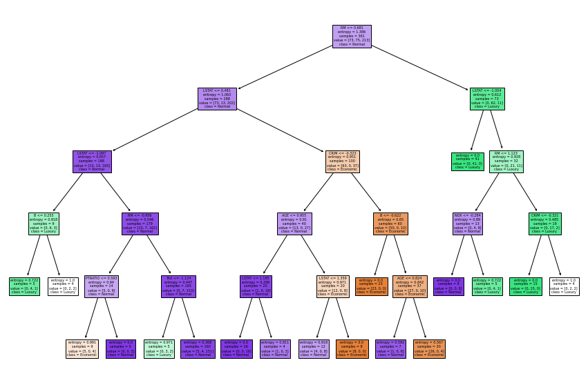

```
✩✩✩✩✩✩✩✩✩✩✩✩✩✩✩✩✩✩✩✩✩✩✩✩✩✩✩✩✩✩✩✩✩✩✩✩✩✩✩✩✩✩✩✩✩✩✩✩✩✩✩✩✩✩✩✩✩✩✩✩✩✩✩✩✩✩✩✩✩✩✩✩✩✩
```

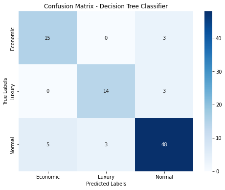

```python
# Divide MEDV to  luxury, economic, and normal houses
luxury_threshold = data['MEDV'].quantile(0.8)
economic_threshold = data['MEDV'].quantile(0.2)

data['House_Category'] = np.where(data['MEDV'] >= luxury_threshold, 'Luxury',np.where(data['MEDV'] <= economic_threshold, 'Economic', 'Normal'))


X = data.drop(columns=['MEDV', 'House_Category'])
y = data['House_Category']

X_train, X_test, y_train, y_test = train_test_split(X, y, test_size=0.2, random_state=42)

decision_tree = DecisionTreeClassifier()

# hyperparameters
param_grid_dt = {
    'criterion': ['gini', 'entropy'],
    'max_depth': [None, 5, 10, 15],
    'min_samples_split': [2, 5, 10],
    'min_samples_leaf': [1, 2, 4]
}

# GridSearchCV for finding the optimal hyperparameters
grid_dt = GridSearchCV(decision_tree, param_grid_dt, cv=5, scoring='accuracy')
grid_dt.fit(X_train, y_train)

best_params_dt = grid_dt.best_params_

optimal_decision_tree = DecisionTreeClassifier(**best_params_dt)
optimal_decision_tree.fit(X_train, y_train)

y_pred_dt = optimal_decision_tree.predict(X_test)

accuracy_dt = accuracy_score(y_test, y_pred_dt)
print("Decision Tree Classifier:")
print("Accuracy:", accuracy_dt)
print("Best Parameters:", best_params_dt)
print(classification_report(y_test, y_pred_dt))

plt.figure(figsize=(15, 10))
plot_tree(optimal_decision_tree, feature_names=X.columns, class_names=['Economic', 'Luxury', 'Normal'], filled=True)
plt.show()

print ("✩✩✩✩✩✩✩✩✩✩✩✩✩✩✩✩✩✩✩✩✩✩✩✩✩✩✩✩✩✩✩✩✩✩✩✩✩✩✩✩✩✩✩✩✩✩✩✩✩✩✩✩✩✩✩✩✩✩✩✩✩✩✩✩✩✩✩✩✩✩✩✩✩✩")

conf_matrix_dt = confusion_matrix(y_test, y_pred_dt)

plt.figure(figsize=(8, 6))
sns.heatmap(conf_matrix_dt, annot=True, cmap="Blues", fmt="d", xticklabels=['Economic', 'Luxury', 'Normal'],
            yticklabels=['Economic', 'Luxury', 'Normal'])
plt.xlabel('Predicted Labels')
plt.ylabel('True Labels')
plt.title('Confusion Matrix - Decision Tree Classifier')
plt.show()
```

### KNN:

```
K-Nearest Neighbors (KNN) Classifier:
Accuracy: 0.8791208791208791
Best Parameters: {'metric': 'manhattan', 'n_neighbors': 5, 'weights': 'distance'}
              precision    recall  f1-score   support

    Economic       0.84      0.89      0.86        18
      Luxury       0.92      0.65      0.76        17
      Normal       0.88      0.95      0.91        56

    accuracy                           0.88        91
   macro avg       0.88      0.83      0.85        91
weighted avg       0.88      0.88      0.88        91

✩✩✩✩✩✩✩✩✩✩✩✩✩✩✩✩✩✩✩✩✩✩✩✩✩✩✩✩✩✩✩✩✩✩✩✩✩✩✩✩✩✩✩✩✩✩✩✩✩✩✩✩✩✩✩✩✩✩✩✩✩✩✩✩✩✩✩✩✩✩✩✩✩✩
```

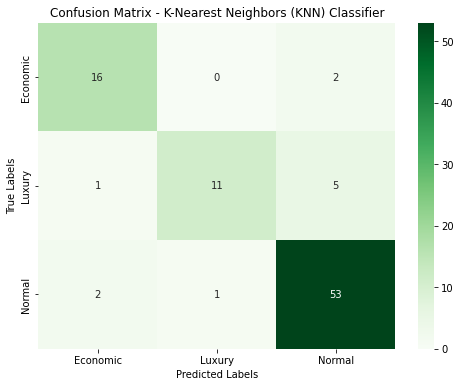

```python
knn = KNeighborsClassifier()

# hyperparameters
param_grid_knn = {
    'n_neighbors': [3, 5, 7, 9],
    'weights': ['uniform', 'distance'],
    'metric': ['euclidean', 'manhattan']
}


grid_knn = GridSearchCV(knn, param_grid_knn, cv=5, scoring='accuracy')
grid_knn.fit(X_train, y_train)

best_params_knn = grid_knn.best_params_

optimal_knn = KNeighborsClassifier(**best_params_knn)
optimal_knn.fit(X_train, y_train)

y_pred_knn = optimal_knn.predict(X_test)

accuracy_knn = accuracy_score(y_test, y_pred_knn)
print("\nK-Nearest Neighbors (KNN) Classifier:")
print("Accuracy:", accuracy_knn)
print("Best Parameters:", best_params_knn)
print(classification_report(y_test, y_pred_knn))

print ("✩✩✩✩✩✩✩✩✩✩✩✩✩✩✩✩✩✩✩✩✩✩✩✩✩✩✩✩✩✩✩✩✩✩✩✩✩✩✩✩✩✩✩✩✩✩✩✩✩✩✩✩✩✩✩✩✩✩✩✩✩✩✩✩✩✩✩✩✩✩✩✩✩✩")

conf_matrix_knn = confusion_matrix(y_test, y_pred_knn)

plt.figure(figsize=(8, 6))
sns.heatmap(conf_matrix_knn, annot=True, cmap="Greens", fmt="d", xticklabels=['Economic', 'Luxury', 'Normal'], yticklabels=['Economic', 'Luxury', 'Normal'])
plt.xlabel('Predicted Labels')
plt.ylabel('True Labels')
plt.title('Confusion Matrix - K-Nearest Neighbors (KNN) Classifier')
plt.show()
```

✨✨✨✨✨✨✨✨✨✨✨✨✨✨✨✨✨✨✨✨✨✨✨✨✨✨✨✨✨✨✨✨✨✨✨✨✨✨✨✨✨✨

## Ensemble Learning:

### 30. Usage of Ensemble methods:

Ensemble methods are used to improve the predictive performance of machine learning models by combining multiple individual models. They are of great importance today because they often result in more accurate and robust predictions compared to single models. By leveraging the diversity among the individual models and combining their predictions, ensemble methods can reduce overfitting, increase generalization ability, and improve the stability of the final model. Ensemble methods are highly adaptable and can be applied to various types of machine learning algorithms, making them a versatile tool in the data scientist's toolkit.

### 31.Boosting & Bagging :

- Bagging (Bootstrap Aggregating):

Bagging involves creating multiple subsets of the training data by sampling with replacement (bootstrap sampling). Each subset is used to train a separate base model (learner) on the dataset independently. The final prediction is made by aggregating the predictions of all base models (e.g., averaging for regression, voting for classification). Bagging helps reduce variance and prevents overfitting by combining multiple models trained on different subsets of the data.

- Boosting:

Boosting works by sequentially training multiple weak learners (models that are slightly better than random guessing) and combining them to create a strong learner. Each weak learner is trained on a modified version of the dataset, where the weights of the misclassified instances are increased in subsequent iterations. The final prediction is made by weighted voting or weighted averaging of the predictions from all weak learners. Boosting focuses on reducing bias and improving accuracy by iteratively correcting the mistakes of previous models.

- Differences :

Bagging builds multiple models independently and combines them, while Boosting builds models sequentially, where each subsequent model corrects the errors of the previous ones.

In Bagging, each model is trained on a random subset of the data with replacement, while in Boosting, each model is trained on a weighted version of the dataset, where the weights are adjusted to focus on the misclassified instances.

Bagging aims to reduce variance and prevent overfitting, while Boosting aims to reduce bias and improve accuracy by focusing on difficult-to-classify instances.

Bagging is often used with high variance, low bias models, while Boosting is effective with high bias, low variance models.

### 32. Random Forest:

Random Forest method is an ensemble learning technique based on the construction of multiple decision trees.It randomly selects a subset of the training data with replacement .This random subset is used to train each decision tree in the forest.

Each decision tree in the Random Forest is trained independently using a different subset of the data. During the training process, at each node of the tree, a random subset of features is considered for splitting, rather than using all features. This introduces diversity among the trees and helps prevent overfitting.

Once all the decision trees are trained, they each make predictions on unseen data. For classification tasks, the final prediction is determined by majority voting among the decision trees. For regression tasks, the final prediction is the average (or mean) of the predictions made by individual trees. Final Prediction:

The aggregated predictions of all decision trees in the forest result in the final prediction for the input data.

### 33. Bootstrapping in Random Forest:

Bootstrapping is a resampling technique used in random forests to create multiple datasets from the original dataset by sampling with replacement. In the context of random forests, bootstrapping involves randomly selecting a subset of observations from the original dataset to train each decision tree.

Bootstrapping affects the results of the model by introducing diversity among the individual decision trees. This diversity is beneficial because it helps reduce overfitting and improves the generalization performance of the random forest model. By training each decision tree on a slightly different subset of data, bootstrapping ensures that the ensemble model captures different aspects of the underlying data distribution, leading to more robust and accurate predictions.

### 34.Number of Decision tree in random forest :

The number of decision trees in a random forest can affect the efficiency and performance of the model. In general, increasing the number of decision trees in the ensemble can lead to better performance up to a certain point, after which adding more trees may have diminishing returns or even lead to overfitting.

There isn't a fixed best value for the number of decision trees in a random forest, as it depends on factors such as the complexity of the dataset, the amount of noise, and the computational resources available. However, increasing the number of trees can improve the model's accuracy and robustness up to a certain point.

Typically, increasing the number of trees beyond a certain threshold will not significantly improve the model's performance but will increase computational time and memory requirements. This threshold varies depending on the dataset and the specific problem being solved. It's common to start with a relatively large number of trees and then use techniques such as cross-validation to determine the optimal number based on performance metrics such as accuracy or mean squared error.

In practice, values such as 100, 500, or 1000 decision trees are often used in random forest models, but the optimal number should be determined empirically through experimentation and validation on the specific dataset.

### 35.When is it not appropriate to use random forest?

When not to use random forest:

- Interpretability: If interpretability of the model is critical and you need to understand the underlying decision-making process, random forests may not be the best choice. Random forests are often considered as "black box" models, meaning it can be challenging to interpret the individual decision trees and how they contribute to the final prediction.
- Small Datasets: Random forests may not perform well on very small datasets, especially when the number of features is much larger than the number of samples. In such cases, random forests may overfit the training data.
- Linear Relationships: When the relationships between features and the target variable are predominantly linear, simpler models like linear regression may be more appropriate. Random forests are better suited for capturing complex nonlinear relationships.

  When to use random forest:
- High-Dimensional Data: Random forests are effective for high-dimensional datasets with many features, as they can handle a large number of input variables without overfitting.
- Large Datasets: Random forests are computationally efficient and can handle large datasets with many samples.
- Nonlinear Relationships: Random forests excel at capturing nonlinear relationships between features and the target variable, making them suitable for a wide range of regression and classification tasks.
- Robustness to Noise: Random forests are robust to noisy data and outliers, as they aggregate predictions from multiple decision trees, reducing the risk of overfitting.
- Ensemble Learning: Random forests are a type of ensemble learning method, which combines multiple models to improve predictive performance. They often outperform individual decision trees and other traditional machine learning algorithms in terms of accuracy and generalization performance.

### 36.Random Forest and variance:

Using random forests can have a significant effect on reducing variance compared to using individual decision trees. This reduction in variance is one of the key advantages of random forests and is achieved through the ensemble nature of the algorithm.By combining multiple decision trees trained on different subsets of data and features, and aggregating their predictions, random forests effectively reduce variance and improve the generalization performance of the model. This makes them less susceptible to overfitting and more robust to variations in the training data, leading to better performance on unseen data.

### 37.Random forest best parameter:

```python
param_grid = {
    'n_estimators': [50, 100, 200],
    'max_depth': [None, 10, 20],
    'min_samples_split': [2, 5, 10],
    'min_samples_leaf': [1, 2, 4],
    'max_features': ['sqrt', 'log2', None]
}


rf_classifier = RandomForestClassifier(random_state=42)

grid_search = GridSearchCV(estimator=rf_classifier, param_grid=param_grid, cv=5, scoring='accuracy', n_jobs=-1)

grid_search.fit(X_train, y_train)

best_params = grid_search.best_params_
best_score = grid_search.best_score_

print("Best parameters found:", best_params)
print("Best cross-validation accuracy:", best_score)

best_estimator = grid_search.best_estimator_
y_pred = best_estimator.predict(X_test)

test_accuracy = accuracy_score(y_test, y_pred)
print("Test set accuracy:", test_accuracy)
```

```
Best parameters found: {'max_depth': None, 'max_features': 'sqrt', 'min_samples_leaf': 1, 'min_samples_split': 2, 'n_estimators': 100}
Best cross-validation accuracy: 0.8645357686453577
Test set accuracy: 0.9010989010989011
```

✨✨✨✨✨✨✨✨✨✨✨✨✨✨✨✨✨✨✨✨✨✨✨✨✨✨✨✨✨✨✨✨✨✨✨✨✨✨✨✨✨✨

## Xgboost:

### 38. XGboost:

XGBoost, short for eXtreme Gradient Boosting, is an optimized distributed gradient boosting library designed to be highly efficient, flexible, and portable. It is an implementation of gradient boosted decision trees designed for speed and performance.

XGBoost combines the strengths of gradient boosting with optimization techniques, regularization, and parallelization to achieve state-of-the-art performance in various machine learning tasks.

### 39.Gradient Boosting & difference between Boosting Tree & Decision Tree:

It is an ensemble learning technique used for classification and regression tasks. It builds a strong predictive model by combining multiple weak models in a sequential manner. The main idea behind gradient boosting is to iteratively improve the performance of the model by fitting new models to the residuals or errors of the previous models.

- Decision Trees: Decision trees are a type of supervised learning algorithm used for both classification and regression tasks. They recursively partition the feature space into regions, with each partition corresponding to a simple prediction rule. Decision trees are often used as weak learners in boosting algorithms.
- Tree Boosting: Tree boosting, or gradient boosting with decision trees, is an ensemble learning technique that combines multiple decision trees sequentially to create a strong predictive model. Unlike standalone decision trees, which may suffer from high bias or variance, tree boosting iteratively improves the performance of the model by fitting new trees to the residuals of the previous predictions. This process leads to a highly accurate and robust predictive model.

### 39+. XGBoost implementation:

```python
label_encoder = LabelEncoder()
y_train_encoded = label_encoder.fit_transform(y_train)

param_grid = {
    'n_estimators': [100, 200, 300],
    'max_depth': [3, 5, 7],
    'learning_rate': [0.1, 0.01, 0.001]
}

xgb_clf = XGBClassifier()

grid_search = GridSearchCV(estimator=xgb_clf, param_grid=param_grid, cv=5)

grid_search.fit(X_train, y_train_encoded)

print("Best Parameters:", grid_search.best_params_)
print("Best Accuracy:", grid_search.best_score_)

y_pred = grid_search.predict(X_test)

y_pred_label = label_encoder.inverse_transform(y_pred)

conf_matrix = confusion_matrix(y_test, y_pred_label)

print("Confusion Matrix:")
print(conf_matrix)

class_report = classification_report(y_test, y_pred_label)

print("Classification Report:")
print(class_report)

f1 = f1_score(y_test, y_pred_label, average='weighted')

print("F1 Score:", f1)
```

```
Best Parameters: {'learning_rate': 0.1, 'max_depth': 7, 'n_estimators': 100}
Best Accuracy: 0.8533485540334855
Confusion Matrix:
[[15  0  3]
 [ 0 15  2]
 [ 5  2 49]]
Classification Report:
              precision    recall  f1-score   support

    Economic       0.75      0.83      0.79        18
      Luxury       0.88      0.88      0.88        17
      Normal       0.91      0.88      0.89        56

    accuracy                           0.87        91
   macro avg       0.85      0.86      0.85        91
weighted avg       0.87      0.87      0.87        91

F1 Score: 0.8692465429307533
```

✨✨✨✨✨✨✨✨✨✨✨✨✨✨✨✨✨✨✨✨✨✨✨✨✨✨✨✨✨✨✨✨✨✨✨✨✨✨✨✨✨✨

## Phase 5 - Support Vector Machine :

```python
X_train, X_test, y_train, y_test = train_test_split(X, y, test_size=0.2, random_state=42)


svm_rbf_model = SVC(kernel='rbf', random_state=42)
svm_rbf_model.fit(X_train, y_train)


preds_rbf = svm_rbf_model.predict(X_test)

accuracy_rbf = accuracy_score(y_test, preds_rbf)
print("Accuracy with RBF Kernel:", accuracy_rbf)

svm_linear_model = SVC(kernel='linear', random_state=42)
svm_linear_model.fit(X_train, y_train)

preds_linear = svm_linear_model.predict(X_test)

accuracy_linear = accuracy_score(y_test, preds_linear)
print("Accuracy with Linear Kernel:", accuracy_linear)
```

```
Accuracy with RBF Kernel: 0.8241758241758241
Accuracy with Linear Kernel: 0.8571428571428571
```

```python
cm_rbf = confusion_matrix(y_test, preds_rbf)
print("Confusion Matrix with RBF Kernel:")
print(cm_rbf)

print("Classification Report with RBF Kernel:")
print(classification_report(y_test, preds_rbf))

cm_linear = confusion_matrix(y_test, preds_linear)
print("Confusion Matrix with Linear Kernel:")
print(cm_linear)

print("Classification Report with Linear Kernel:")
print(classification_report(y_test, preds_linear))
```

```
Confusion Matrix with RBF Kernel:
[[14  0  4]
 [ 1 11  5]
 [ 3  3 50]]
Classification Report with RBF Kernel:
              precision    recall  f1-score   support

    Economic       0.78      0.78      0.78        18
      Luxury       0.79      0.65      0.71        17
      Normal       0.85      0.89      0.87        56

    accuracy                           0.82        91
   macro avg       0.80      0.77      0.79        91
weighted avg       0.82      0.82      0.82        91

Confusion Matrix with Linear Kernel:
[[16  0  2]
 [ 0 13  4]
 [ 4  3 49]]
Classification Report with Linear Kernel:
              precision    recall  f1-score   support

    Economic       0.80      0.89      0.84        18
      Luxury       0.81      0.76      0.79        17
      Normal       0.89      0.88      0.88        56

    accuracy                           0.86        91
   macro avg       0.83      0.84      0.84        91
weighted avg       0.86      0.86      0.86        91
```

### 40-3. Grid Search & Random Search :

For tuning the hyperparameters of SVM models, both Grid Search and Random Search methods can be used effectively. However, the choice between them depends on various factors such as the size of the hyperparameter search space, computational resources available, and the desired level of optimization.

If you have limited computational resources or a large hyperparameter search space, Random Search may be preferred because it can provide good results with fewer evaluations. On the other hand, if you have sufficient computational resources and a relatively small search space, Grid Search can be more thorough in finding the optimal hyperparameters.

### GRID SEARCH :

```python
X_train, X_test, y_train, y_test = train_test_split(X, y, test_size=0.2, random_state=42)

param_grid_rbf = {
    'C': [0.1, 1, 10],
    'gamma': [0.1, 0.01, 0.001],
}

svm_rbf = SVC(kernel='rbf')

grid_search_rbf = GridSearchCV(estimator=svm_rbf, param_grid=param_grid_rbf, cv=5)

grid_search_rbf.fit(X_train, y_train)

print("Best Parameters (RBF):", grid_search_rbf.best_params_)
print("Best Score (RBF):", grid_search_rbf.best_score_)

param_grid_linear = {
    'C': [0.1, 1, 10],
}

svm_linear = SVC(kernel='linear')

grid_search_linear = GridSearchCV(estimator=svm_linear, param_grid=param_grid_linear, cv=5)

grid_search_linear.fit(X_train, y_train)

print("Best Parameters (Linear):", grid_search_linear.best_params_)
print("Best Score (Linear):", grid_search_linear.best_score_)
```

```
Best Parameters (RBF): {'C': 1, 'gamma': 0.1}
Best Score (RBF): 0.8534246575342465
Best Parameters (Linear): {'C': 10}
Best Score (Linear): 0.8616057838660577
```

### RANDOM SEARCH :

```python
X_train, X_test, y_train, y_test = train_test_split(X, y, test_size=0.2, random_state=42)

param_dist_rbf = {
    'C': reciprocal(0.1, 10),
    'gamma': reciprocal(0.001, 0.1),
}

svm_rbf = SVC(kernel='rbf')

random_search_rbf = RandomizedSearchCV(estimator=svm_rbf, param_distributions=param_dist_rbf, n_iter=10, cv=5)

random_search_rbf.fit(X_train, y_train)

print("Best Parameters (RBF):", random_search_rbf.best_params_)
print("Best Score (RBF):", random_search_rbf.best_score_)

param_dist_linear = {
    'C': uniform(0.1, 10),
}

svm_linear = SVC(kernel='linear')

random_search_linear = RandomizedSearchCV(estimator=svm_linear, param_distributions=param_dist_linear, n_iter=10, cv=5)

random_search_linear.fit(X_train, y_train)

print("Best Parameters (Linear):", random_search_linear.best_params_)
print("Best Score (Linear):", random_search_linear.best_score_)
```

```
Best Parameters (RBF): {'C': 3.2003211644891594, 'gamma': 0.0625562743007187}
Best Score (RBF): 0.8478310502283104
Best Parameters (Linear): {'C': 6.143346991912239}
Best Score (Linear): 0.8588660578386605
```

```
                                    🌌
```